# Reproducible documents with Quarto

Day 3 - Introduction to Data Analysis with R

Selina Baldauf

Freie Universität Berlin - Theoretical Ecology

October 17, 2026

## From R scripts to documents

So far, you’ve been writing `.R` scripts.

This is great for running code, but what if you want to

- share your analysis with collaborators?
- add explanations and interpretations to your code?
- create a report with figures and tables?

## A standard workflow

[figure not shown]

If you have to repeat the analysis

- Redo all figures and tables
- Update document manually
- Manual copy pasting of values is very error prone

## A Quarto workflow

**Quarto** lets you combine **code**, **text**, and **output** in one document.

[figure not shown]

**Advantages:**

- Easy to redo the analysis
- No more copy pasting
- Reproducible
- Documentation, code & output in one place

## What is Quarto?

> Quarto is an open-source scientific and technical publishing system
- Built into RStudio but can also be installed separately
- Create different types of outputs:
  - Documents: HTML, PDF, Word
  - Presentations, Websites, Books, …

Today we focus on **documents**.

# A first Quarto document

More info online: [Get started with Quarto in RStudio](https://quarto.org/docs/get-started/hello/rstudio.html)

## Create a Quarto document

`File` -> `New File` -> `Quarto Document...`

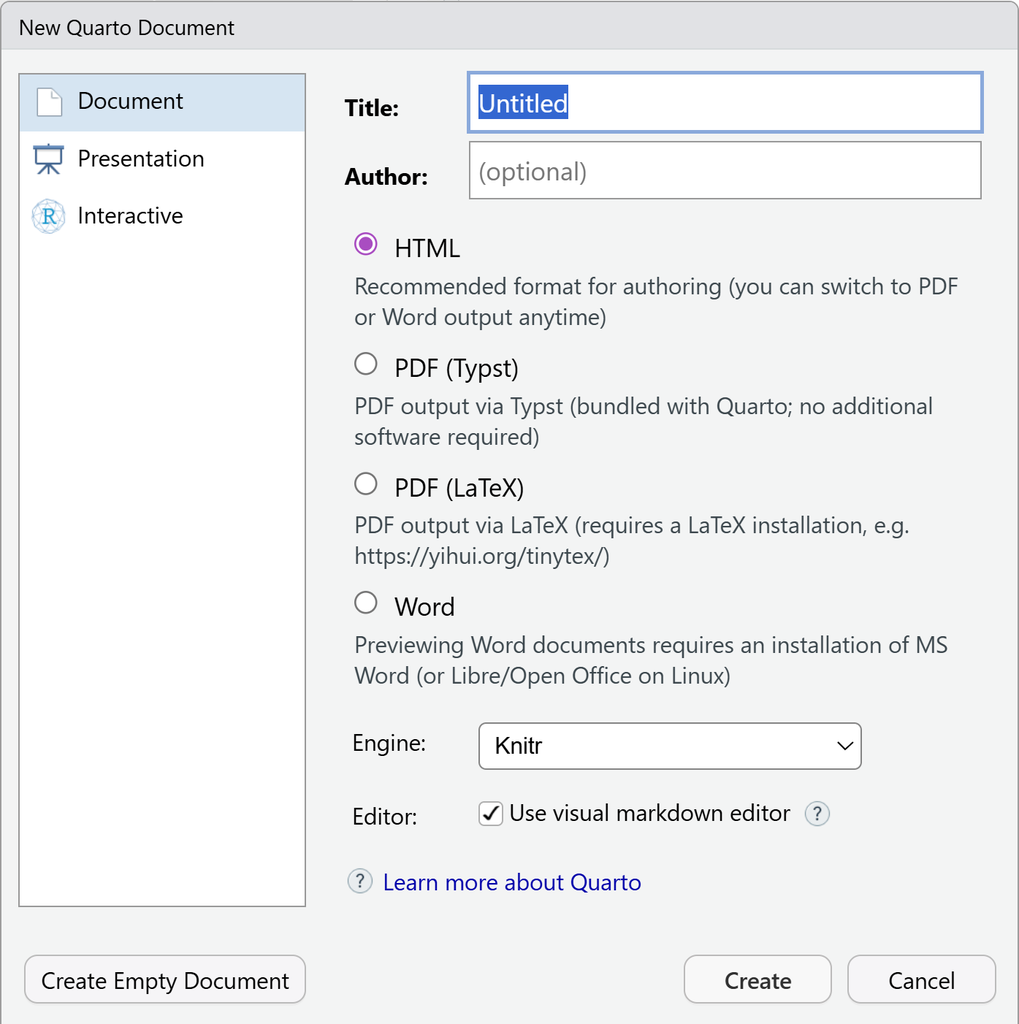

- Choose a title and the output format
- Choose the editor: visual or source
- The new document already contains example text

## Render the document

- Click the **Render** button in RStudio
- Or use the keyboard shortcut `Ctrl + Shift + K`

RStudio will run all the code, combine it with your text, and produce the output document.

## Visual and source editor

[figure not shown]

- **Visual**: format text and insert images, tables or links with buttons, similar to Word
- **Source**: write the text with markdown syntax
- You can switch between both at any time

## Three parts of a `.qmd` document

A `.qmd` file has three types of content:

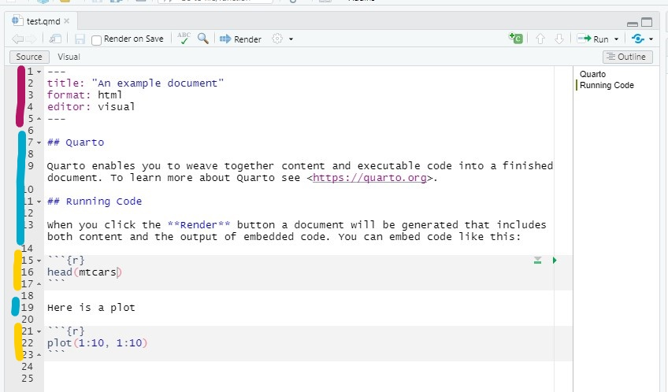

- YAML header: Metadata and output format
- Markdown text: Formatted text body
- Code chunks: R code that produces output

# Markdown text

More online: [Markdown basics](https://quarto.org/docs/authoring/markdown-basics.html)

## Markdown text

Markdown is a simple markup language to create formatted text.

**The basics**

- Bold: `**text**` becomes **text**
- Italic: `*text*` becomes *text*

**Headers**

```markdown
# First level header
## Second level header
### Third level header
```

## Markdown text

**Lists**

```markdown
- item 1
- item 2
- item 3
```

**Links**

`[Quarto website](https://quarto.org)` becomes [Quarto website](https://quarto.org)

You don’t need to memorize all of this. [Here](https://quarto.org/docs/authoring/markdown-basics.html) is a quick reference.

# Adding Code

More online: [Using R in Quarto](https://quarto.org/docs/computations/r.html)

## Code chunks

Code chunks start and end with 3 backticks and contain R code:

````markdown
```{r}
library(tidyverse)
library(gapminder)

ggplot(gapminder, aes(x = gdpPercap, y = lifeExp)) +
  geom_point()
```
````

**Insert a code chunk**

- Menu: `Code` -> `Insert chunk`
- Keyboard shortcut: `Ctrl + Alt + I` / `Cmd + Option + I`

## Code chunks

**Run a code chunk**

- Code chunks are run when you **render** the document
- You can also run them like normal R code by clicking the green arrow

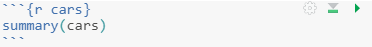

## Code chunk options

Code chunks have special comments starting with `#|` that control the output:

````markdown
```{r}
#| echo: false
#| warning: false

ggplot(gapminder, aes(x = gdpPercap, y = lifeExp)) +
  geom_point()
```
````

- `echo`: Show the code in the output?
- `eval`: Run the code?
- `include`: Show code **and** output? (the code still runs)
- `warning`: Show warnings?
- `message`: Show messages?

All options take `true` or `false`.

## Inline code

You can also include R code **inside text** using inline code:

```markdown
The gapminder data contains `r nrow(gapminder)` observations.
```

becomes:

The gapminder data contains 1704 observations.

This means **numbers update automatically** when the data changes.

# YAML header (metadata)

More online: [HTML document options](https://quarto.org/docs/reference/formats/html.html)

## YAML header (metadata)

The YAML header is at the top of the document between `---` markers:

```yaml
---
title: "My analysis"
author: "Selina Baldauf"
date: today
format: html
editor: visual
---
```

This sets the **title**, **author**, **date**, **output format**, and **editor**.

## Execute options

You can set **default options** for all code chunks:

```yaml
---
title: "My analysis"
author: "Selina Baldauf"
format: html
execute:
  warning: false
  message: false
---
```

These can be overwritten by individual chunk options.

# Now you

Task (30 min)

Reproducible documents with Quarto

**Find the task description [here](https://selinazitrone.github.io/intro-r-data-analysis/sessions/tasks/quarto-task.html)**

# Additional Quarto features

## Render to PDF

Change the output format in the YAML header:

```yaml
---
format: pdf
---
```

You might need to install LaTeX first. The most convenient is to use the [`tinytex` package](https://yihui.org/tinytex/):

```r
# Run this in the R console
# install.packages("tinytex")
tinytex::install_tinytex()
```

## Render to Word

```yaml
---
format: docx
---
```

You can also specify **multiple output formats**:

```yaml
---
format:
  html: default
  pdf: default
  docx: default
---
```

## Document options

Add options to the YAML header to customize your document:

```yaml
---
format: html
toc: true
toc-location: left
number-sections: true
code-fold: true
---
```

- `toc`: Add a table of contents
- `number-sections`: Number the section headers
- `code-fold`: Hide code behind a button (HTML only)

## Figure options

Control how figures appear in the output:

````markdown
```{r}
#| label: fig-life-exp
#| fig-cap: "Life expectancy vs. GDP per capita in 2007"
#| fig-align: center
#| out-width: "80%"

ggplot(gapminder, aes(x = gdpPercap, y = lifeExp)) +
  geom_point(aes(color = continent)) +
  theme_minimal()
```
````

- `fig-cap`: Figure caption
- `fig-align`: `left`, `center`, or `right`
- `out-width`: Width of the figure in the output
- `label`: Must start with `fig-` for figures

## Cross-references

You can reference labeled figures in the text:

```markdown
As we can see in @fig-life-exp, life expectancy increases with GDP.
```

becomes:

As we can see in Figure 1, life expectancy increases with GDP.

## Nice tables with `kable()`

By default, tibbles print as plain text. Use `knitr::kable()` to render a nice table:

````markdown
```{r}
gapminder |>
  filter(year == 2007) |>
  group_by(continent) |>
  summarize(
    mean_life_exp = mean(lifeExp),
    mean_gdp = mean(gdpPercap)
  ) |>
  knitr::kable()
```
````

| continent | mean_life_exp | mean_gdp |
| --- | --- | --- |
| Africa | 54.80604 | 3089.033 |
| Americas | 73.60812 | 11003.032 |
| Asia | 70.72848 | 12473.027 |
| Europe | 77.64860 | 25054.482 |
| Oceania | 80.71950 | 29810.188 |

## Outlook

Quarto can do much more:

- **Presentations** (like the slides in this workshop)
- **Websites** (like the [workshop website](https://selinazitrone.github.io/intro-r-data-analysis/))
- **Books**
- Publish online with [Quarto Pub](https://quartopub.com/) or GitHub Pages

Check out the [Quarto website](https://quarto.org/) for guides, examples, and a gallery.

## References

- [Quarto website](https://quarto.org/): everything you need to get started
- [Markdown syntax reference](https://quarto.org/docs/authoring/markdown-basics.html)
- [HTML document options](https://quarto.org/docs/reference/formats/html.html)
- [PDF document options](https://quarto.org/docs/reference/formats/pdf.html)
- [Gallery with examples](https://quarto.org/docs/gallery/)